# Supervised Learning - Foundations Project: ReCell

Question 6: A lot of devices nowadays offer great selfie cameras, allowing us to capture our favorite moments with loved ones. What is the distribution of devices offering greater than 8MP selfie cameras across brands?

```python
data_selfie_camera = data[data.selfie_camera_mp > 8]
data_selfie_camera.shape
```

```
(655, 15)
```

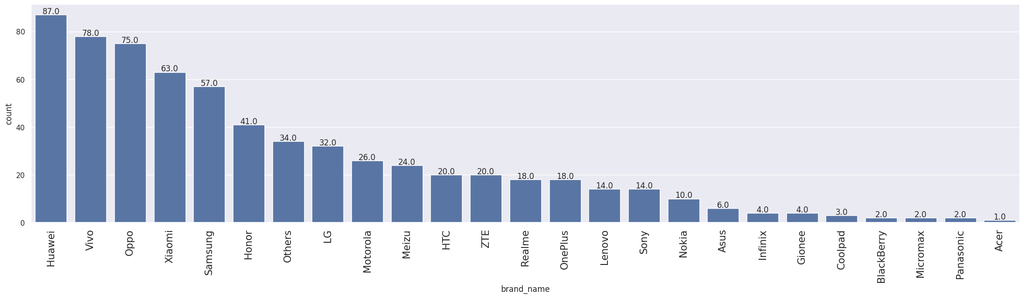

```python
labeled_barplot(data=data_selfie_camera, feature='brand_name') ## Pass both the DataFrame and feature name to the function
```

*Observations*

There are 655 devices offering greater than 8MP selfie cameras across brands. The labeled barplot gives a breakdown of these devices in terms of their brand.

**Let's do a similar analysis for rear cameras.**

- Rear cameras generally have a better resolution than front cameras, so we set the threshold higher for them at 16MP.

```python
data_main_camera = data[data.main_camera_mp > 16]
data_main_camera.shape
```

```
(94, 15)
```

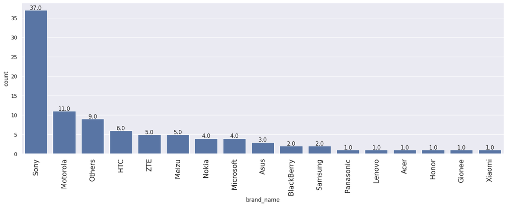

```python
labeled_barplot(data=data_main_camera, feature='brand_name') ## Pass both the DataFrame and feature name to the function
```

*Observations*

There are 94 devices offering greater than 16MP main cameras across brands. The labeled barplot gives a breakdown of these devices in terms of their brand.

Question 7: Which attributes are highly correlated with the normalized price of a used device?

**Let's see how the price of used devices varies across the years.**

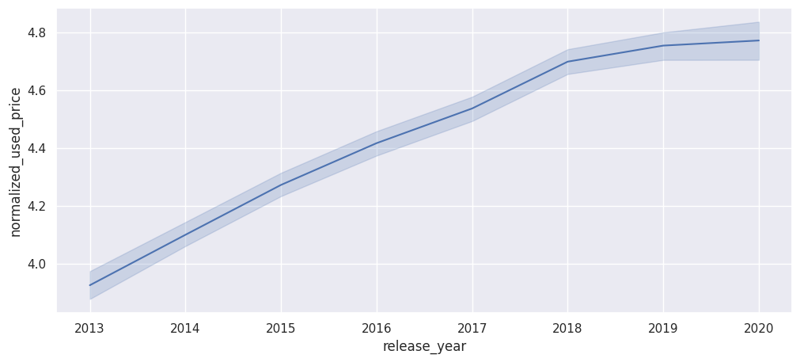

```python
#How the price of used device varies across the years.
plt.figure(figsize=(12, 5))
sns.lineplot(data=data , x='release_year' , y='normalized_used_price')
plt.show()
```

*Observations*

1. A relationship between the release year and the normalized used price can be established. Overall, there is an upward trend: the more recent the year of release-from 2013 to 2020-the more expensive the normalised used price. Thus, it can be expected that the more recently released the device, the higher the normalised used price.
2. Knowing this may be important when devising a pricing strategy for used devices and predicting market value.

**Let's check how the prices vary for used phones and tablets offering 4G and 5G networks.**

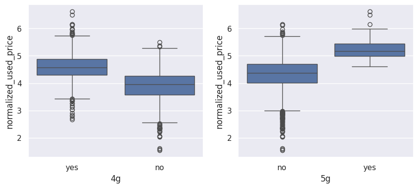

```python
plt.figure(figsize=(10, 4))

plt.subplot(121)
sns.boxplot(data=data, x="4g", y="normalized_used_price")

plt.subplot(122)
sns.boxplot(data=data, x="5g", y="normalized_used_price")

plt.show()
```

*Observations*

4G

Generally, the prices of used devices that support 4G are higher; note the higher median and more concentrated distribution of prices around 4.5 euros.

The devices that do not have 4G have a wider range with a lower median value, and more lower end outliers in their price distribution, reflecting that devices that do not possess 4G may be variably priced possibly due to factors such as age or model.

5G

## Data Preprocessing

- Missing value treatment
- Feature engineering (if needed)
- Outlier detection and treatment (if needed)
- Preparing data for modeling
- Any other preprocessing steps (if needed)

*Missing Value Imputation*

- We will impute the missing values in the data by the column medians grouped by `release_year` and `brand_name`.

```python
# let's create a copy of the data
df1 = data.copy()
```

```python
# Check for missing values
df1.isnull().sum()
```

|  | 0 |
| --- | --- |
| brand_name | 0 |
| os | 0 |
| screen_size | 0 |
| 4g | 0 |
| 5g | 0 |
| main_camera_mp | 179 |
| selfie_camera_mp | 2 |
| int_memory | 4 |
| ram | 4 |
| battery | 6 |
| weight | 7 |
| release_year | 0 |
| days_used | 0 |
| normalized_used_price | 0 |
| normalized_new_price | 0 |

**dtype:** int64

*Observations*

There are missing values in the dataset. These are:

main_camera_mp 179

selfie_camera_mp 2

int_memory 4

ram 4

battery 6

weight 7

```python
 cols_impute = [
    "main_camera_mp",
    "selfie_camera_mp",
    "int_memory",
    "ram",
    "battery",
    "weight",
]

for col in cols_impute:
    df1[col] = df1[col].fillna(
        value=df1.groupby(['release_year', 'brand_name'])[col].transform("median") # Replaced '_____' with 'release_year' and 'brand_name'
    )   ## Complete the code to impute missing values in cols_impute with median by grouping the data on release year and brand name

# checking for missing values
df1.isnull().sum() ## Complete the code to check missing values after imputing the above columns
```

|  | 0 |
| --- | --- |
| brand_name | 0 |
| os | 0 |
| screen_size | 0 |
| 4g | 0 |
| 5g | 0 |
| main_camera_mp | 179 |
| selfie_camera_mp | 2 |
| int_memory | 0 |
| ram | 0 |
| battery | 6 |
| weight | 7 |
| release_year | 0 |
| days_used | 0 |
| normalized_used_price | 0 |
| normalized_new_price | 0 |

**dtype:** int64

- We will impute the remaining missing values in the data by the column medians grouped by `brand_name`.

```python
cols_impute = [
    "main_camera_mp",
    "selfie_camera_mp",
    "battery",
    "weight",
]

for col in cols_impute:
    df1[col] = df1[col].fillna(
        value=df1.groupby(['brand_name'])[col].transform("median") # Replaced '_____' with 'brand_name' to group by brand name
    ) ## Complete the code to impute the missing values in cols_impute with median by grouping the data on brand name

# checking for missing values
df1.isnull().sum() ## Complete the code to check missing values after imputing the above columns
```

|  | 0 |
| --- | --- |
| brand_name | 0 |
| os | 0 |
| screen_size | 0 |
| 4g | 0 |
| 5g | 0 |
| main_camera_mp | 10 |
| selfie_camera_mp | 0 |
| int_memory | 0 |
| ram | 0 |
| battery | 0 |
| weight | 0 |
| release_year | 0 |
| days_used | 0 |
| normalized_used_price | 0 |
| normalized_new_price | 0 |

**dtype:** int64

- We will fill the remaining missing values in the `main_camera_mp` column by the column median.

```python
df1["main_camera_mp"] = df1["main_camera_mp"].fillna(df1["main_camera_mp"].median()) ## Complete the code to impute the data with median

# checking for missing values
df1.isnull().sum() ## Complete the code to check missing values after imputing the above columns
```

|  | 0 |
| --- | --- |
| brand_name | 0 |
| os | 0 |
| screen_size | 0 |
| 4g | 0 |
| 5g | 0 |
| main_camera_mp | 0 |
| selfie_camera_mp | 0 |
| int_memory | 0 |
| ram | 0 |
| battery | 0 |
| weight | 0 |
| release_year | 0 |
| days_used | 0 |
| normalized_used_price | 0 |
| normalized_new_price | 0 |

**dtype:** int64

*Observations*

All missing values have been treated.

## EDA

- It is a good idea to explore the data once again after manipulating it.

```python
# check for missing values
df1.isnull().sum()
```

|  | 0 |
| --- | --- |
| brand_name | 0 |
| os | 0 |
| screen_size | 0 |
| 4g | 0 |
| 5g | 0 |
| main_camera_mp | 0 |
| selfie_camera_mp | 0 |
| int_memory | 0 |
| ram | 0 |
| battery | 0 |
| weight | 0 |
| release_year | 0 |
| days_used | 0 |
| normalized_used_price | 0 |
| normalized_new_price | 0 |

**dtype:** int64

```python
#check for duplicated entries
df1.duplicated().sum()
```

```
0
```

### Feature Engineering

- Let's create a new column `years_since_release` from the `release_year` column.
- We will consider the year of data collection, 2021, as the baseline.
- We will drop the `release_year` column.

```python
df1["years_since_release"] = 2021 - df1["release_year"]
df1.drop("release_year", axis=1, inplace=True)
df1["years_since_release"].describe()
```

|  | years_since_release |
| --- | --- |
| count | 3454.000000 |
| mean | 5.034742 |
| std | 2.298455 |
| min | 1.000000 |
| 25% | 3.000000 |
| 50% | 5.500000 |
| 75% | 7.000000 |
| max | 8.000000 |

**dtype:** float64

### Outlier Check

- Let's check for outliers in the data.

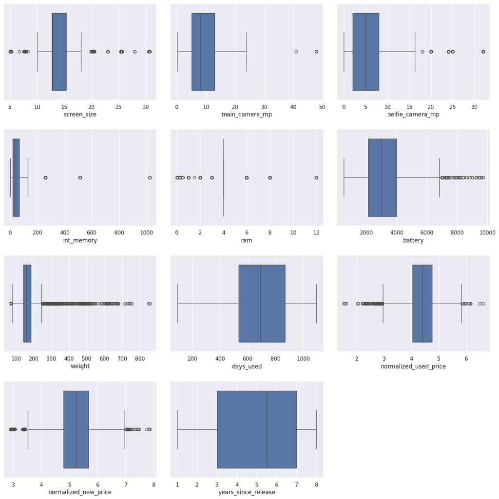

```python
# outlier detection using boxplot
num_cols = df1.select_dtypes(include=np.number).columns.tolist()

plt.figure(figsize=(15, 15))

for i, variable in enumerate(num_cols):
    plt.subplot(4, 3, i + 1)
    sns.boxplot(data=df1, x=variable)
    plt.tight_layout(pad=2)

plt.show()
```

*Observations*

The data contains a lot of outliers

### Data Preparation for modeling

- We want to predict the normalized price of used devices
- Before we proceed to build a model, we'll have to encode categorical features
- We'll split the data into train and test to be able to evaluate the model that we build on the train data
- We will build a Linear Regression model using the train data and then check it's performance.

```python
# define the dependent and independent variables
X = df1.drop('normalized_used_price', axis=1)
y = df1['normalized_used_price']
print(X.head())
print()
print(y.head())
```

```
  brand_name       os  screen_size   4g   5g  main_camera_mp  \
0      Honor  Android        14.50  yes   no            13.0
1      Honor  Android        17.30  yes  yes            13.0
2      Honor  Android        16.69  yes  yes            13.0
3      Honor  Android        25.50  yes  yes            13.0
4      Honor  Android        15.32  yes   no            13.0

   selfie_camera_mp  int_memory  ram  battery  weight  days_used  \
0               5.0        64.0  3.0   3020.0   146.0        127
1              16.0       128.0  8.0   4300.0   213.0        325
2               8.0       128.0  8.0   4200.0   213.0        162
3               8.0        64.0  6.0   7250.0   480.0        345
4               8.0        64.0  3.0   5000.0   185.0        293

   normalized_new_price  years_since_release
0              4.715100                    1
1              5.519018                    1
2              5.884631                    1
3              5.630961                    1
4              4.947837                    1

0    4.307572
1    5.162097
2    5.111084
3    5.135387
4    4.389995
Name: normalized_used_price, dtype: float64
```

```python
# let's add the intercept to data
X = sm.add_constant(X)
```

```python
# creating dummy variables
X = pd.get_dummies(
    X,
    columns=X.select_dtypes(include=["object", "category"]).columns.tolist(),
    drop_first=True,
)  ## Complete the code to create dummies for independent features

X.head()
```

|  | const | screen_size | main_camera_mp | selfie_camera_mp | int_memory | ram | battery | weight | days_used | normalized_new_price | ... | brand_name_Spice | brand_name_Vivo | brand_name_XOLO | brand_name_Xiaomi | brand_name_ZTE | os_Others | os_Windows | os_iOS | 4g_yes | 5g_yes |
| --- | --- | --- | --- | --- | --- | --- | --- | --- | --- | --- | --- | --- | --- | --- | --- | --- | --- | --- | --- | --- | --- |
| 0 | 1.0 | 14.50 | 13.0 | 5.0 | 64.0 | 3.0 | 3020.0 | 146.0 | 127 | 4.715100 | ... | False | False | False | False | False | False | False | False | True | False |
| 1 | 1.0 | 17.30 | 13.0 | 16.0 | 128.0 | 8.0 | 4300.0 | 213.0 | 325 | 5.519018 | ... | False | False | False | False | False | False | False | False | True | True |
| 2 | 1.0 | 16.69 | 13.0 | 8.0 | 128.0 | 8.0 | 4200.0 | 213.0 | 162 | 5.884631 | ... | False | False | False | False | False | False | False | False | True | True |
| 3 | 1.0 | 25.50 | 13.0 | 8.0 | 64.0 | 6.0 | 7250.0 | 480.0 | 345 | 5.630961 | ... | False | False | False | False | False | False | False | False | True | True |
| 4 | 1.0 | 15.32 | 13.0 | 8.0 | 64.0 | 3.0 | 5000.0 | 185.0 | 293 | 4.947837 | ... | False | False | False | False | False | False | False | False | True | False |

5 rows × 49 columns

```python
# Converting the input attributes into float type for modeling
X = X.astype(float)
X.head()
```

|  | const | screen_size | main_camera_mp | selfie_camera_mp | int_memory | ram | battery | weight | days_used | normalized_new_price | ... | brand_name_Spice | brand_name_Vivo | brand_name_XOLO | brand_name_Xiaomi | brand_name_ZTE | os_Others | os_Windows | os_iOS | 4g_yes | 5g_yes |
| --- | --- | --- | --- | --- | --- | --- | --- | --- | --- | --- | --- | --- | --- | --- | --- | --- | --- | --- | --- | --- | --- |
| 0 | 1.0 | 14.50 | 13.0 | 5.0 | 64.0 | 3.0 | 3020.0 | 146.0 | 127.0 | 4.715100 | ... | 0.0 | 0.0 | 0.0 | 0.0 | 0.0 | 0.0 | 0.0 | 0.0 | 1.0 | 0.0 |
| 1 | 1.0 | 17.30 | 13.0 | 16.0 | 128.0 | 8.0 | 4300.0 | 213.0 | 325.0 | 5.519018 | ... | 0.0 | 0.0 | 0.0 | 0.0 | 0.0 | 0.0 | 0.0 | 0.0 | 1.0 | 1.0 |
| 2 | 1.0 | 16.69 | 13.0 | 8.0 | 128.0 | 8.0 | 4200.0 | 213.0 | 162.0 | 5.884631 | ... | 0.0 | 0.0 | 0.0 | 0.0 | 0.0 | 0.0 | 0.0 | 0.0 | 1.0 | 1.0 |
| 3 | 1.0 | 25.50 | 13.0 | 8.0 | 64.0 | 6.0 | 7250.0 | 480.0 | 345.0 | 5.630961 | ... | 0.0 | 0.0 | 0.0 | 0.0 | 0.0 | 0.0 | 0.0 | 0.0 | 1.0 | 1.0 |
| 4 | 1.0 | 15.32 | 13.0 | 8.0 | 64.0 | 3.0 | 5000.0 | 185.0 | 293.0 | 4.947837 | ... | 0.0 | 0.0 | 0.0 | 0.0 | 0.0 | 0.0 | 0.0 | 0.0 | 1.0 | 0.0 |

5 rows × 49 columns

```python
# splitting the data in 70:30 ratio for training and  testing data respectively
x_train, x_test, y_train, y_test = train_test_split(X, y, test_size=0.3, random_state=123)
```

```python
print("Number of rows in train data =", x_train.shape[0])
print("Number of rows in test data =", x_test.shape[0])
```

```
Number of rows in train data = 2417
Number of rows in test data = 1037
```

*Observations*

Of the 3454 rows in the dataset, training data is 2417 and testing data is 1037, respresenting 70% and 30% respectively

## Model Building - Linear Regression

```python
olsmodel1 = sm.OLS(y_train, x_train).fit()
print(olsmodel1.summary())
```

```
                              OLS Regression Results
=================================================================================
Dep. Variable:     normalized_used_price   R-squared:                       0.847
Model:                               OLS   Adj. R-squared:                  0.844
Method:                    Least Squares   F-statistic:                     272.7
Date:                   Thu, 10 Oct 2024   Prob (F-statistic):               0.00
Time:                           12:59:31   Log-Likelihood:                 131.85
No. Observations:                   2417   AIC:                            -165.7
Df Residuals:                       2368   BIC:                             118.0
Df Model:                             48
Covariance Type:               nonrobust
=========================================================================================
                            coef    std err          t      P>|t|      [0.025      0.975]
-----------------------------------------------------------------------------------------
const                     1.4038      0.069     20.331      0.000       1.268       1.539
screen_size               0.0272      0.003      8.233      0.000       0.021       0.034
main_camera_mp            0.0202      0.001     13.609      0.000       0.017       0.023
selfie_camera_mp          0.0150      0.001     13.041      0.000       0.013       0.017
int_memory             -9.04e-06   6.95e-05     -0.130      0.897      -0.000       0.000
ram                       0.0200      0.005      3.851      0.000       0.010       0.030
battery               -1.589e-05   7.36e-06     -2.158      0.031   -3.03e-05   -1.45e-06
weight                    0.0009      0.000      7.125      0.000       0.001       0.001
days_used               2.61e-05   3.11e-05      0.840      0.401   -3.48e-05     8.7e-05
normalized_new_price      0.4169      0.012     34.392      0.000       0.393       0.441
years_since_release      -0.0206      0.005     -4.446      0.000      -0.030      -0.012
brand_name_Alcatel       -0.0435      0.046     -0.957      0.339      -0.133       0.046
brand_name_Apple          0.0298      0.147      0.204      0.839      -0.258       0.317
brand_name_Asus           0.0098      0.047      0.210      0.834      -0.082       0.101
brand_name_BlackBerry     0.0749      0.075      0.995      0.320      -0.073       0.223
brand_name_Celkon        -0.1285      0.064     -2.016      0.044      -0.254      -0.003
brand_name_Coolpad       -0.0220      0.070     -0.314      0.753      -0.160       0.115
brand_name_Gionee        -0.0070      0.053     -0.131      0.896      -0.111       0.097
brand_name_Google        -0.0307      0.081     -0.379      0.704      -0.189       0.128
brand_name_HTC           -0.0128      0.047     -0.273      0.785      -0.105       0.079
brand_name_Honor          0.0110      0.047      0.232      0.817      -0.082       0.104
brand_name_Huawei        -0.0353      0.043     -0.823      0.410      -0.119       0.049
brand_name_Infinix        0.1053      0.092      1.140      0.254      -0.076       0.286
brand_name_Karbonn        0.0452      0.067      0.673      0.501      -0.087       0.177
brand_name_LG            -0.0537      0.043     -1.237      0.216      -0.139       0.031
brand_name_Lava          -0.0526      0.067     -0.788      0.431      -0.184       0.078
```

[output cut: 19 more lines]

```
os_Windows               -0.0330      0.044     -0.754      0.451      -0.119       0.053
os_iOS                   -0.1895      0.149     -1.274      0.203      -0.481       0.102
4g_yes                    0.0624      0.016      3.906      0.000       0.031       0.094
5g_yes                   -0.0589      0.032     -1.862      0.063      -0.121       0.003
==============================================================================
Omnibus:                      233.970   Durbin-Watson:                   1.992
Prob(Omnibus):                  0.000   Jarque-Bera (JB):              612.536
Skew:                          -0.543   Prob(JB):                    9.76e-134
Kurtosis:                       5.214   Cond. No.                     1.73e+05
==============================================================================

Notes:
[1] Standard Errors assume that the covariance matrix of the errors is correctly specified.
[2] The condition number is large, 1.73e+05. This might indicate that there are
strong multicollinearity or other numerical problems.
```

*Observations*

### Interpreting the Regression Results:

1. **Adjusted. R-squared**: It reflects the fit of the model.
   - Adjusted R-squared values generally range from 0 to 1, where a higher value generally indicates a better fit, assuming certain conditions are met.
   - In our case, the value for adj. R-squared is **0.844**, which is good.
1. *const* coefficient: It is the Y-intercept.
   - It means that if all the predictor variable coefficients are zero, then the expected output (i.e., Y) would be equal to the *const* coefficient.
   - In our case, the value for `const` coefficient is **1.4038**

```python
# Convert all columns in X to numeric if possible.
# Errors='coerce' will replace non-numeric values with NaN.
for col in X.select_dtypes(include=['object']).columns:
    try:
        # Explicitly convert to numeric, handle errors by setting to NaN
        X[col] = pd.to_numeric(X[col], errors='coerce')
    except (ValueError, TypeError):
        # If conversion fails, drop the column and print a warning
        print(f"Column '{col}' cannot be converted to numeric and will be dropped.")
        X = X.drop(columns=[col])

# Impute NaN values using a strategy appropriate for numeric data
# Consider using mean, median, or a more sophisticated imputation method.
# Here, we use the mean for demonstration.
for col in X.select_dtypes(include=np.number).columns:
    X[col] = X[col].fillna(X[col].mean())

# Check if y is a pandas Series and convert it to a numpy array
if isinstance(y, pd.Series):
    y = y.to_numpy()

# *** The fix: Convert all columns in X to numeric dtype ***
X = X.astype(float)

# Fit the OLS model
olsmodel1 = sm.OLS(y, X).fit()
print(olsmodel1.summary())
```

```
                            OLS Regression Results
==============================================================================
Dep. Variable:                      y   R-squared:                       0.845
Model:                            OLS   Adj. R-squared:                  0.843
Method:                 Least Squares   F-statistic:                     388.0
Date:                Thu, 10 Oct 2024   Prob (F-statistic):               0.00
Time:                        12:59:31   Log-Likelihood:                 152.64
No. Observations:                3454   AIC:                            -207.3
Df Residuals:                    3405   BIC:                             93.94
Df Model:                          48
Covariance Type:            nonrobust
=========================================================================================
                            coef    std err          t      P>|t|      [0.025      0.975]
-----------------------------------------------------------------------------------------
const                     1.3455      0.059     22.991      0.000       1.231       1.460
screen_size               0.0263      0.003      9.386      0.000       0.021       0.032
main_camera_mp            0.0213      0.001     16.888      0.000       0.019       0.024
selfie_camera_mp          0.0136      0.001     14.073      0.000       0.012       0.015
int_memory             6.858e-05   5.32e-05      1.289      0.198   -3.58e-05       0.000
ram                       0.0228      0.004      5.192      0.000       0.014       0.031
battery               -1.738e-05   6.27e-06     -2.773      0.006   -2.97e-05   -5.09e-06
weight                    0.0009      0.000      8.449      0.000       0.001       0.001
days_used              4.194e-05   2.56e-05      1.638      0.101   -8.25e-06    9.21e-05
normalized_new_price      0.4281      0.010     41.809      0.000       0.408       0.448
years_since_release      -0.0253      0.004     -6.628      0.000      -0.033      -0.018
brand_name_Alcatel       -0.0262      0.039     -0.668      0.504      -0.103       0.051
brand_name_Apple         -0.0062      0.144     -0.043      0.965      -0.288       0.275
brand_name_Asus           0.0327      0.039      0.836      0.403      -0.044       0.110
brand_name_BlackBerry     0.0501      0.061      0.815      0.415      -0.070       0.171
brand_name_Celkon        -0.1347      0.054     -2.478      0.013      -0.241      -0.028
brand_name_Coolpad        0.0161      0.060      0.268      0.789      -0.102       0.134
brand_name_Gionee         0.0032      0.046      0.071      0.943      -0.086       0.093
brand_name_Google        -0.0071      0.070     -0.102      0.919      -0.143       0.129
brand_name_HTC           -0.0103      0.040     -0.257      0.797      -0.089       0.068
brand_name_Honor          0.0109      0.040      0.272      0.786      -0.068       0.090
brand_name_Huawei        -0.0170      0.037     -0.464      0.643      -0.089       0.055
brand_name_Infinix        0.1454      0.082      1.770      0.077      -0.016       0.307
brand_name_Karbonn       -0.0167      0.055     -0.304      0.761      -0.124       0.091
brand_name_LG            -0.0316      0.037     -0.852      0.394      -0.104       0.041
brand_name_Lava           0.0085      0.051      0.166      0.868      -0.092       0.109
```

[output cut: 19 more lines]

```
os_Windows               -0.0178      0.038     -0.473      0.636      -0.091       0.056
os_iOS                   -0.0816      0.144     -0.566      0.572      -0.364       0.201
4g_yes                    0.0455      0.013      3.400      0.001       0.019       0.072
5g_yes                   -0.0631      0.026     -2.418      0.016      -0.114      -0.012
==============================================================================
Omnibus:                      312.142   Durbin-Watson:                   1.898
Prob(Omnibus):                  0.000   Jarque-Bera (JB):              715.062
Skew:                          -0.553   Prob(JB):                    5.32e-156
Kurtosis:                       4.935   Cond. No.                     1.81e+05
==============================================================================

Notes:
[1] Standard Errors assume that the covariance matrix of the errors is correctly specified.
[2] The condition number is large, 1.81e+05. This might indicate that there are
strong multicollinearity or other numerical problems.
```

## Model Performance Check

**Let's check the performance of the model using different metrics.**

- We will be using metric functions defined in sklearn for RMSE, MAE, and $R^2$.
- We will define a function to calculate MAPE and adjusted $R^2$.
- We will create a function which will print out all the above metrics in one go.

```python
# function to compute adjusted R-squared
def adj_r2_score(predictors, targets, predictions):
    r2 = r2_score(targets, predictions)
    n = predictors.shape[0]
    k = predictors.shape[1]
    return 1 - ((1 - r2) * (n - 1) / (n - k - 1))


# function to compute MAPE
def mape_score(targets, predictions):
    return np.mean(np.abs(targets - predictions) / targets) * 100


# function to compute different metrics to check performance of a regression model
def model_performance_regression(model, predictors, target):
    """
    Function to compute different metrics to check regression model performance

    model: regressor
    predictors: independent variables
    target: dependent variable
    """

    # predicting using the independent variables
    pred = model.predict(predictors)

    r2 = r2_score(target, pred)  # to compute R-squared
    adjr2 = adj_r2_score(predictors, target, pred)  # to compute adjusted R-squared
    rmse = np.sqrt(mean_squared_error(target, pred))  # to compute RMSE
    mae = mean_absolute_error(target, pred)  # to compute MAE
    mape = mape_score(target, pred)  # to compute MAPE

    # creating a dataframe of metrics
    df_perf = pd.DataFrame(
        {
            "RMSE": rmse,
            "MAE": mae,
            "R-squared": r2,
            "Adj. R-squared": adjr2,
            "MAPE": mape,
        },
        index=[0],
    )

    return df_perf
```

```python
# checking model performance on training data (70% data)
print("Training Performance\n")
olsmodel1_train_perf = model_performance_regression(olsmodel1, x_train, y_train)
olsmodel1_train_perf
```

```
Training Performance
```

|  | RMSE | MAE | R-squared | Adj. R-squared | MAPE |
| --- | --- | --- | --- | --- | --- |
| 0 | 0.2301 | 0.179147 | 0.84549 | 0.842291 | 4.319393 |

```python
# checking model performance on testing data (30% data)
print("Test Performance\n")
olsmodel1_test_perf = model_performance_regression(olsmodel1, x_test, y_test)
olsmodel1_test_perf
```

```
Test Performance
```

|  | RMSE | MAE | R-squared | Adj. R-squared | MAPE |
| --- | --- | --- | --- | --- | --- |
| 0 | 0.234766 | 0.183708 | 0.845174 | 0.837488 | 4.387554 |

*Observations*

## Checking Linear Regression Assumptions

- In order to make statistical inferences from a linear regression model, it is important to ensure that the assumptions of linear regression are satisfied.

# We will be checking the following Linear Regression assumptions:

1. **No Multicollinearity**
2. **Linearity of variables**
3. **Independence of error terms**
4. **Normality of error terms**
5. **No Heteroscedasticity**

### TEST FOR MULTICOLLINEARITY

- We will test for multicollinearity using VIF.
- **General Rule of thumb**:
  - If VIF is 1 then there is no correlation between the predictor and the remaining predictor variables.
  - If VIF exceeds 5 or is close to exceeding 5, we say there is moderate multicollinearity.
  - If VIF is 10 or exceeding 10, it shows signs of high multicollinearity.

```python
from statsmodels.stats.outliers_influence import variance_inflation_factor


def checking_vif(predictors):
    vif = pd.DataFrame()
    vif["feature"] = predictors.columns

    # calculating VIF for each feature
    vif["VIF"] = [
        variance_inflation_factor(predictors.values, i)
        for i in range(len(predictors.columns))
    ]
    return vif
```

```python
checking_vif(x_train)
```

|  | feature | VIF |
| --- | --- | --- |
| 0 | const | 215.036913 |
| 1 | screen_size | 7.278752 |
| 2 | main_camera_mp | 2.264119 |
| 3 | selfie_camera_mp | 2.842852 |
| 4 | int_memory | 1.386133 |
| 5 | ram | 2.284200 |
| 6 | battery | 4.225265 |
| 7 | weight | 6.013562 |
| 8 | days_used | 2.705157 |
| 9 | normalized_new_price | 3.103060 |
| 10 | years_since_release | 5.105715 |
| 11 | brand_name_Alcatel | 3.421939 |
| 12 | brand_name_Apple | 9.525415 |
| 13 | brand_name_Asus | 3.054816 |
| 14 | brand_name_BlackBerry | 1.474197 |
| 15 | brand_name_Celkon | 1.801918 |
| 16 | brand_name_Coolpad | 1.457833 |
| 17 | brand_name_Gionee | 2.082980 |
| 18 | brand_name_Google | 1.336840 |
| 19 | brand_name_HTC | 3.077727 |
| 20 | brand_name_Honor | 3.261239 |
| 21 | brand_name_Huawei | 5.714094 |
| 22 | brand_name_Infinix | 1.267700 |
| 23 | brand_name_Karbonn | 1.504295 |
| 24 | brand_name_LG | 4.737891 |
| 25 | brand_name_Lava | 1.568644 |
| 26 | brand_name_Lenovo | 4.334003 |
| 27 | brand_name_Meizu | 2.250861 |
| 28 | brand_name_Micromax | 3.141050 |
| 29 | brand_name_Microsoft | 1.849420 |
| 30 | brand_name_Motorola | 3.320691 |
| 31 | brand_name_Nokia | 3.323766 |
| 32 | brand_name_OnePlus | 1.423294 |
| 33 | brand_name_Oppo | 3.291307 |
| 34 | brand_name_Others | 8.845364 |
| 35 | brand_name_Panasonic | 1.987559 |
| 36 | brand_name_Realme | 1.919913 |
| 37 | brand_name_Samsung | 6.950280 |
| 38 | brand_name_Sony | 2.742757 |
| 39 | brand_name_Spice | 1.601507 |
| 40 | brand_name_Vivo | 3.354176 |
| 41 | brand_name_XOLO | 1.807099 |
| 42 | brand_name_Xiaomi | 3.616557 |
| 43 | brand_name_ZTE | 3.607571 |
| 44 | os_Others | 1.766115 |
| 45 | os_Windows | 1.649642 |
| 46 | os_iOS | 8.599224 |
| 47 | 4g_yes | 2.508764 |
| 48 | 5g_yes | 1.809417 |

*Observations*

### Removing Multicollinearity

Let's define a function that will help us do this.

```python
def treating_multicollinearity(predictors, target, high_vif_columns):
    """
    Checking the effect of dropping the columns showing high multicollinearity
    on model performance (adj. R-squared and RMSE)

    predictors: independent variables
    target: dependent variable
    high_vif_columns: columns having high VIF
    """
    # empty lists to store adj. R-squared and RMSE values
    adj_r2 = []
    rmse = []

    # build ols models by dropping one of the high VIF columns at a time
    # store the adjusted R-squared and RMSE in the lists defined previously
    for cols in high_vif_columns:
        # defining the new train set
        train = predictors.loc[:, ~predictors.columns.str.startswith(cols)]

        # create the model
        olsmodel = sm.OLS(target, train).fit()

        # adding adj. R-squared and RMSE to the lists
        adj_r2.append(olsmodel.rsquared_adj)
        rmse.append(np.sqrt(olsmodel.mse_resid))

    # creating a dataframe for the results
    temp = pd.DataFrame(
        {
            "col": high_vif_columns,
            "Adj. R-squared after_dropping col": adj_r2,
            "RMSE after dropping col": rmse,
        }
    ).sort_values(by="Adj. R-squared after_dropping col", ascending=False)
    temp.reset_index(drop=True, inplace=True)

    return temp
```

```python
col_list = ["brand_name_Apple", "os_iOS"]

res = treating_multicollinearity(x_train, y_train, col_list)
res
```

|  | col | Adj. R-squared after_dropping col | RMSE after dropping col |
| --- | --- | --- | --- |
| 0 | brand_name_Apple | 0.843754 | 0.231437 |
| 1 | os_iOS | 0.843650 | 0.231514 |

```python
col_to_drop = "os_iOS"
x_train2 = x_train.loc[:, ~x_train.columns.str.startswith(col_to_drop)]
x_test2 = x_test.loc[:, ~x_test.columns.str.startswith(col_to_drop)]

# Check VIF now
vif = checking_vif(x_train2)
print("VIF after dropping ", col_to_drop)
vif
```

```
VIF after dropping  os_iOS
```

|  | feature | VIF |
| --- | --- | --- |
| 0 | const | 213.809303 |
| 1 | screen_size | 7.206418 |
| 2 | main_camera_mp | 2.262279 |
| 3 | selfie_camera_mp | 2.830454 |
| 4 | int_memory | 1.386035 |
| 5 | ram | 2.268640 |
| 6 | battery | 4.219769 |
| 7 | weight | 5.989356 |
| 8 | days_used | 2.704151 |
| 9 | normalized_new_price | 3.102820 |
| 10 | years_since_release | 5.104478 |
| 11 | brand_name_Alcatel | 3.421729 |
| 12 | brand_name_Apple | 1.766261 |
| 13 | brand_name_Asus | 3.054741 |
| 14 | brand_name_BlackBerry | 1.471310 |
| 15 | brand_name_Celkon | 1.801908 |
| 16 | brand_name_Coolpad | 1.457768 |
| 17 | brand_name_Gionee | 2.082893 |
| 18 | brand_name_Google | 1.336629 |
| 19 | brand_name_HTC | 3.077511 |
| 20 | brand_name_Honor | 3.260743 |
| 21 | brand_name_Huawei | 5.713398 |
| 22 | brand_name_Infinix | 1.267688 |
| 23 | brand_name_Karbonn | 1.503940 |
| 24 | brand_name_LG | 4.737890 |
| 25 | brand_name_Lava | 1.568176 |
| 26 | brand_name_Lenovo | 4.333919 |
| 27 | brand_name_Meizu | 2.250852 |
| 28 | brand_name_Micromax | 3.140895 |
| 29 | brand_name_Microsoft | 1.849322 |
| 30 | brand_name_Motorola | 3.320690 |
| 31 | brand_name_Nokia | 3.321961 |
| 32 | brand_name_OnePlus | 1.422920 |
| 33 | brand_name_Oppo | 3.291232 |
| 34 | brand_name_Others | 8.845289 |
| 35 | brand_name_Panasonic | 1.987520 |
| 36 | brand_name_Realme | 1.919739 |
| 37 | brand_name_Samsung | 6.949662 |
| 38 | brand_name_Sony | 2.742750 |
| 39 | brand_name_Spice | 1.601165 |
| 40 | brand_name_Vivo | 3.353762 |
| 41 | brand_name_XOLO | 1.807026 |
| 42 | brand_name_Xiaomi | 3.616414 |
| 43 | brand_name_ZTE | 3.607496 |
| 44 | os_Others | 1.659701 |
| 45 | os_Windows | 1.648284 |
| 46 | 4g_yes | 2.507945 |
| 47 | 5g_yes | 1.803689 |

```python
olsmod1 = sm.OLS(y_train, x_train2).fit()
print(olsmod1.summary())
```

```
                              OLS Regression Results
=================================================================================
Dep. Variable:     normalized_used_price   R-squared:                       0.847
Model:                               OLS   Adj. R-squared:                  0.844
Method:                    Least Squares   F-statistic:                     278.4
Date:                   Thu, 10 Oct 2024   Prob (F-statistic):               0.00
Time:                           12:59:33   Log-Likelihood:                 131.02
No. Observations:                   2417   AIC:                            -166.0
Df Residuals:                       2369   BIC:                             111.9
Df Model:                             47
Covariance Type:               nonrobust
=========================================================================================
                            coef    std err          t      P>|t|      [0.025      0.975]
-----------------------------------------------------------------------------------------
const                     1.3971      0.069     20.290      0.000       1.262       1.532
screen_size               0.0276      0.003      8.401      0.000       0.021       0.034
main_camera_mp            0.0203      0.001     13.649      0.000       0.017       0.023
selfie_camera_mp          0.0149      0.001     12.983      0.000       0.013       0.017
int_memory            -9.785e-06   6.96e-05     -0.141      0.888      -0.000       0.000
ram                       0.0206      0.005      3.969      0.000       0.010       0.031
battery               -1.555e-05   7.36e-06     -2.113      0.035      -3e-05   -1.12e-06
weight                    0.0009      0.000      7.057      0.000       0.001       0.001
days_used              2.533e-05    3.1e-05      0.816      0.415   -3.56e-05    8.62e-05
normalized_new_price      0.4170      0.012     34.400      0.000       0.393       0.441
years_since_release      -0.0207      0.005     -4.466      0.000      -0.030      -0.012
brand_name_Alcatel       -0.0440      0.046     -0.967      0.334      -0.133       0.045
brand_name_Apple         -0.1387      0.063     -2.197      0.028      -0.262      -0.015
brand_name_Asus           0.0095      0.047      0.204      0.839      -0.082       0.101
brand_name_BlackBerry     0.0707      0.075      0.939      0.348      -0.077       0.218
brand_name_Celkon        -0.1283      0.064     -2.013      0.044      -0.253      -0.003
brand_name_Coolpad       -0.0215      0.070     -0.306      0.760      -0.159       0.116
brand_name_Gionee        -0.0065      0.053     -0.123      0.902      -0.111       0.098
brand_name_Google        -0.0320      0.081     -0.395      0.693      -0.191       0.127
brand_name_HTC           -0.0123      0.047     -0.262      0.793      -0.105       0.080
brand_name_Honor          0.0102      0.047      0.216      0.829      -0.082       0.103
brand_name_Huawei        -0.0359      0.043     -0.837      0.403      -0.120       0.048
brand_name_Infinix        0.1049      0.092      1.136      0.256      -0.076       0.286
brand_name_Karbonn        0.0465      0.067      0.692      0.489      -0.085       0.178
brand_name_LG            -0.0537      0.043     -1.237      0.216      -0.139       0.031
brand_name_Lava          -0.0512      0.067     -0.766      0.444      -0.182       0.080
```

[output cut: 18 more lines]

```
os_Others                -0.0846      0.032     -2.683      0.007      -0.146      -0.023
os_Windows               -0.0314      0.044     -0.717      0.473      -0.117       0.054
4g_yes                    0.0621      0.016      3.883      0.000       0.031       0.093
5g_yes                   -0.0612      0.032     -1.936      0.053      -0.123       0.001
==============================================================================
Omnibus:                      234.315   Durbin-Watson:                   1.991
Prob(Omnibus):                  0.000   Jarque-Bera (JB):              609.139
Skew:                          -0.546   Prob(JB):                    5.33e-133
Kurtosis:                       5.204   Cond. No.                     1.70e+05
==============================================================================

Notes:
[1] Standard Errors assume that the covariance matrix of the errors is correctly specified.
[2] The condition number is large, 1.7e+05. This might indicate that there are
strong multicollinearity or other numerical problems.
```

### Dropping high p-value variables (if needed)

- We will drop the predictor variables having a p-value greater than 0.05 as they do not significantly impact the target variable.
- But sometimes p-values change after dropping a variable. So, we'll not drop all variables at once.
- Instead, we will do the following:
  - Build a model, check the p-values of the variables, and drop the column with the highest p-value.
  - Create a new model without the dropped feature, check the p-values of the variables, and drop the column with the highest p-value.
  - Repeat the above two steps till there are no columns with p-value > 0.05.

The above process can also be done manually by picking one variable at a time that has a high p-value, dropping it, and building a model again. But that might be a little tedious and using a loop will be more efficient.

```python
# initial list of columns
predictors = x_train2.copy()
cols = predictors.columns.tolist()

# setting an initial max p-value
max_p_value = 1

while len(cols) > 0:
    # defining the train set
    x_train_aux = predictors[cols]

    # fitting the model
    model = sm.OLS(y_train, x_train_aux).fit()

    # getting the p-values and the maximum p-value
    p_values = model.pvalues
    max_p_value = max(p_values)

    # name of the variable with maximum p-value
    feature_with_p_max = p_values.idxmax()

    if max_p_value > 0.05:
        cols.remove(feature_with_p_max)
    else:
        break

selected_features = cols
print(selected_features)
```

```
['const', 'screen_size', 'main_camera_mp', 'selfie_camera_mp', 'ram', 'weight', 'normalized_new_price', 'years_since_release', 'brand_name_Celkon', 'brand_name_Xiaomi', 'os_Others', '4g_yes']
```

```python
x_train3 = x_train2[selected_features] ## Complete the code to specify the train data from which to select the specified columns
x_test3 = x_test2[selected_features] ## Complete the code to specify the test data from which to select the specified columns
```

```python
olsmod2 = sm.OLS(y_train, x_train3).fit()
print(olsmod2.summary())
```

```
                              OLS Regression Results
=================================================================================
Dep. Variable:     normalized_used_price   R-squared:                       0.844
Model:                               OLS   Adj. R-squared:                  0.843
Method:                    Least Squares   F-statistic:                     1184.
Date:                   Thu, 10 Oct 2024   Prob (F-statistic):               0.00
Time:                           12:59:33   Log-Likelihood:                 110.59
No. Observations:                   2417   AIC:                            -197.2
Df Residuals:                       2405   BIC:                            -127.7
Df Model:                             11
Covariance Type:               nonrobust
========================================================================================
                           coef    std err          t      P>|t|      [0.025      0.975]
----------------------------------------------------------------------------------------
const                    1.4342      0.051     28.367      0.000       1.335       1.533
screen_size              0.0267      0.003      8.719      0.000       0.021       0.033
main_camera_mp           0.0210      0.001     15.458      0.000       0.018       0.024
selfie_camera_mp         0.0149      0.001     13.689      0.000       0.013       0.017
ram                      0.0155      0.004      3.532      0.000       0.007       0.024
weight                   0.0008      0.000      6.740      0.000       0.001       0.001
normalized_new_price     0.4023      0.011     37.365      0.000       0.381       0.423
years_since_release     -0.0158      0.004     -4.505      0.000      -0.023      -0.009
brand_name_Celkon       -0.1178      0.049     -2.405      0.016      -0.214      -0.022
brand_name_Xiaomi        0.0835      0.025      3.361      0.001       0.035       0.132
os_Others               -0.0941      0.029     -3.222      0.001      -0.151      -0.037
4g_yes                   0.0572      0.015      3.855      0.000       0.028       0.086
==============================================================================
Omnibus:                      249.411   Durbin-Watson:                   1.979
Prob(Omnibus):                  0.000   Jarque-Bera (JB):              684.604
Skew:                          -0.563   Prob(JB):                    2.19e-149
Kurtosis:                       5.352   Cond. No.                     2.36e+03
==============================================================================

Notes:
[1] Standard Errors assume that the covariance matrix of the errors is correctly specified.
[2] The condition number is large, 2.36e+03. This might indicate that there are
strong multicollinearity or other numerical problems.
```

```python
# checking model performance on train set (seen 70% data)
print("Training Performance\n")
olsmod2_train_perf = model_performance_regression(olsmod2, x_train3, y_train)
olsmod2_train_perf
```

```
Training Performance
```

|  | RMSE | MAE | R-squared | Adj. R-squared | MAPE |
| --- | --- | --- | --- | --- | --- |
| 0 | 0.231149 | 0.179771 | 0.844078 | 0.843299 | 4.341622 |

```python
# checking model performance on test set (seen 30% data)
print("Test Performance\n")
olsmod2_test_perf = model_performance_regression(olsmod2, x_test3, y_test)
olsmod2_test_perf
```

```
Test Performance
```

|  | RMSE | MAE | R-squared | Adj. R-squared | MAPE |
| --- | --- | --- | --- | --- | --- |
| 0 | 0.239601 | 0.186729 | 0.838732 | 0.836842 | 4.465106 |

*Observations*

1. Adjusted R-squared is 0.844. That is, our model is able to explain 84% of the variance.
2. RMSE and MAE values are comparable for train and test sets, indicating that the model is not overfitting
3. MAE suggests that the model can predict prices within a mean error of 0.18 on the test data.
4. The testing data has a MAPE of 4.46%, an indication that we are able to predict within 4.46% of the prices.